# Assignment for Unit 9

Fabio

7/7/2019

# Dependencies

### This are the libraries that we will be using in this project.

```r
library(dplyr)
library(ggplot2)
library(tidyr)
library(reshape2)
library(tidyverse)
library(stringr)
```

# Question A

### We are loading the dataset from the beers and the dataset from the Breweries.

```r
url<-"https://raw.githubusercontent.com/BivinSadler/MSDS-6306-Doing-Data-Science/master/Unit%207/Beers.csv"
beers <- read.csv(url(url), sep = ",", header = TRUE)
head(beers)
```

```
##                  Name Beer_ID   ABV IBU Brewery_id
## 1            Pub Beer    1436 0.050  NA        409
## 2         Devil's Cup    2265 0.066  NA        178
## 3 Rise of the Phoenix    2264 0.071  NA        178
## 4            Sinister    2263 0.090  NA        178
## 5       Sex and Candy    2262 0.075  NA        178
## 6        Black Exodus    2261 0.077  NA        178
##                            Style Ounces
## 1            American Pale Lager     12
## 2        American Pale Ale (APA)     12
## 3                   American IPA     12
## 4 American Double / Imperial IPA     12
## 5                   American IPA     12
## 6                  Oatmeal Stout     12
```

```r
url<-"https://raw.githubusercontent.com/BivinSadler/MSDS-6306-Doing-Data-Science/master/Unit%207/Breweries.csv"
brew <- read.csv(url(url), sep = ",", header = TRUE)
head(brew)
```

```
##   Brew_ID                      Name          City State
## 1       1        NorthGate Brewing    Minneapolis    MN
## 2       2 Against the Grain Brewery    Louisville    KY
## 3       3  Jack's Abby Craft Lagers    Framingham    MA
## 4       4 Mike Hess Brewing Company     San Diego    CA
## 5       5   Fort Point Beer Company San Francisco    CA
## 6       6     COAST Brewing Company    Charleston    SC
```

### We clean the data.

```r
# changing from factor to char
brew$State <- as.character(brew$State)
# changing to int
brew$Brew_ID <- as.integer(brew$Brew_ID)
# changing to char
brew$Name <-  as.character(brew$Name)
# removing trailing whitespace with str_trim
str_trim(brew$State, side = "left") -> brew$State
# Cleaning to combine bataset
beers$Brew_ID<-beers$Brewery_id
beers$Brewery_id<-NULL
```

### We combined the 2 tadaset.

```r
combined<- merge(brew, beers, by = "Brew_ID")
# renaming Name.x to Brewery_Name
colnames(combined)[2] <- "Brewery_Name"
# renaming Name.y to Beer_Name
colnames(combined)[5] <- "Beer_Name"
head(combined)
```

```
##   Brew_ID       Brewery_Name        City State     Beer_Name Beer_ID   ABV
## 1       1 NorthGate Brewing  Minneapolis    MN       Pumpion    2689 0.060
## 2       1 NorthGate Brewing  Minneapolis    MN    Stronghold    2688 0.060
## 3       1 NorthGate Brewing  Minneapolis    MN   Parapet ESB    2687 0.056
## 4       1 NorthGate Brewing  Minneapolis    MN  Get Together    2692 0.045
## 5       1 NorthGate Brewing  Minneapolis    MN Maggie's Leap    2691 0.049
## 6       1 NorthGate Brewing  Minneapolis    MN    Wall's End    2690 0.048
##   IBU                               Style Ounces
## 1  38                         Pumpkin Ale     16
## 2  25                     American Porter     16
## 3  47 Extra Special / Strong Bitter (ESB)     16
## 4  50                        American IPA     16
## 5  26                  Milk / Sweet Stout     16
## 6  19                   English Brown Ale     16
```

### Create one new dataset for Colorado and Texas.

```r
na.omit(combined) %>% filter(State %in% c("TX","CO"))%>% arrange(IBU) ->beerCOTX
head(beerCOTX)
```

```
##   Brew_ID               Brewery_Name           City State
## 1      67   Freetail Brewing Company    San Antonio    TX
## 2     129   Real Ale Brewing Company         Blanco    TX
## 3     392       Breckenridge Brewery         Denver    CO
## 4      38      Avery Brewing Company        Boulder    CO
## 5      67   Freetail Brewing Company    San Antonio    TX
## 6     188 Pedernales Brewing Company Fredericksburg    TX
##               Beer_Name Beer_ID   ABV IBU                   Style Ounces
## 1    Yo Soy Un Berliner    2520 0.044   5      Berliner Weissbier     12
## 2 18th Anniversary Gose    2370 0.044   5                    Gose     12
## 3           Agave Wheat    1522 0.042   9 American Pale Wheat Ale     12
## 4          White Rascal     108 0.056  10                 Witbier     12
## 5               Rye Wit    2522 0.042  10                 Witbier     12
## 6             Lobo Lito    2238 0.040  12             Light Lager     12
```

# Question B

### We plot the relationship between ABV and IBU in Texas and Colorado

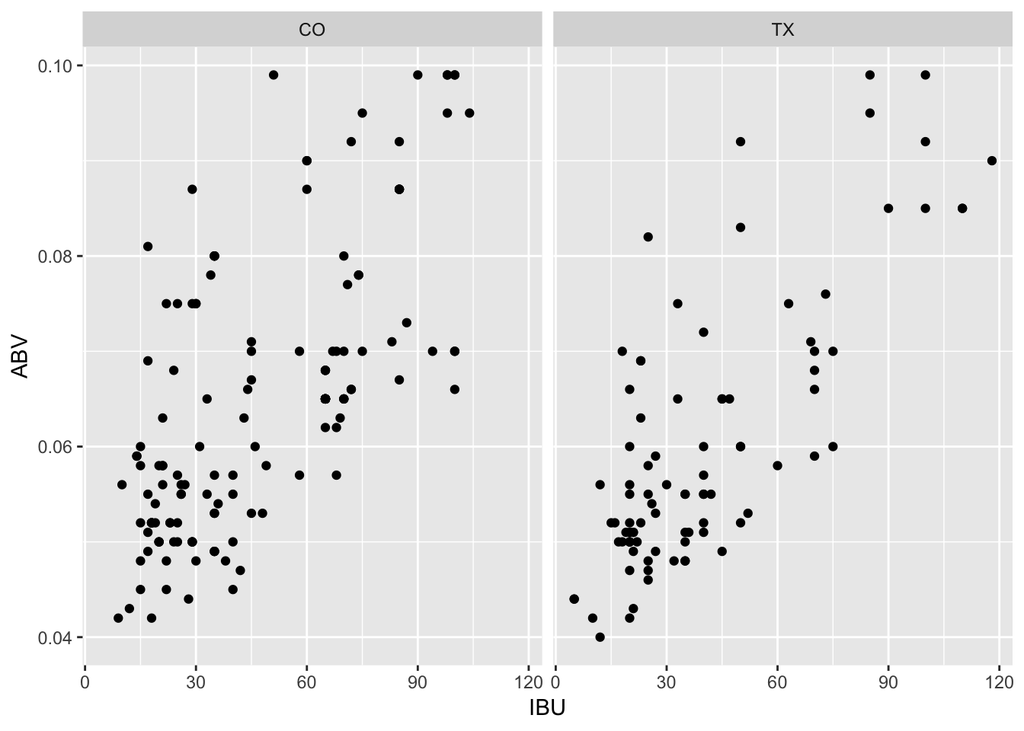

```r
p1= ggplot(beerCOTX, aes(x=IBU, y=ABV) )
p2= p1+ geom_point()
p3= p2 + facet_wrap(State ~ .)
p3
```

### We plot the relationship between ABV and IBU in Texas and Colorado,in a different way.

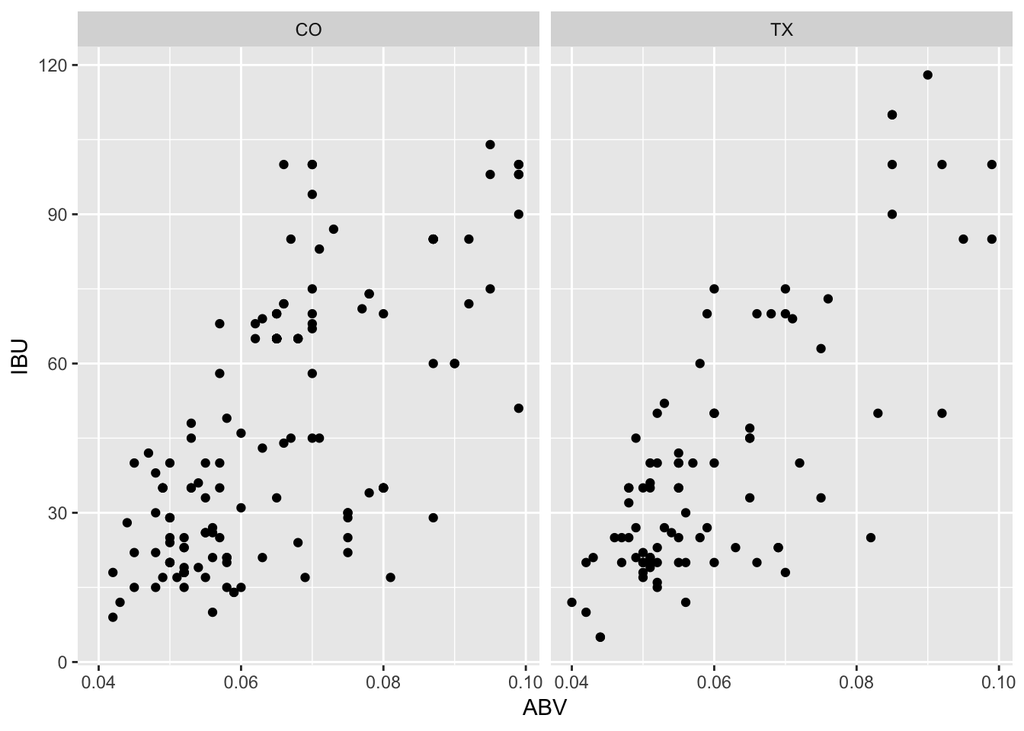

```r
g1= ggplot(beerCOTX, aes(x=ABV, y=IBU) )
g2= g1+ geom_point()
g3= g2 + facet_wrap(State ~ .)
g3
```

Question C

### We plot the relationship between ABV and IBU for the state of Texas

```r
na.omit(combined) %>% filter(State=="TX") ->beerTX
head(beerTX)
```

```
##   Brew_ID              Brewery_Name             City State
## 1      30       Cedar Creek Brewery     Seven Points    TX
## 2      30       Cedar Creek Brewery     Seven Points    TX
## 3      30       Cedar Creek Brewery     Seven Points    TX
## 4      30       Cedar Creek Brewery     Seven Points    TX
## 5      30       Cedar Creek Brewery     Seven Points    TX
## 6      39 Twisted X Brewing Company Dripping Springs    TX
##                        Beer_Name Beer_ID   ABV IBU
## 1                The Lawn Ranger    1050 0.050  18
## 2 Elliott's Phoned Home Pale Ale    1182 0.051  36
## 3           Scruffy's Smoked Alt    1584 0.051  35
## 4                    Dankosaurus    2052 0.068  70
## 5                     Gone A-Rye    2600 0.085  90
## 6                      Twisted X    2212 0.051  19
##                            Style Ounces
## 1                      Cream Ale     16
## 2        American Pale Ale (APA)     16
## 3                    Smoked Beer     16
## 4                   American IPA     16
## 5 American Double / Imperial IPA     16
## 6         American Adjunct Lager     12
```

```r
plot(beerTX$ABV ~ beerTX$IBU, main= "ABV Vs IBU in Texas", xlab = "IBU", ylab = "ABV")
tx_lmt <- lm(beerTX$ABV ~ beerTX$IBU)
summary(tx_lmt)
```

```
##
## Call:
## lm(formula = beerTX$ABV ~ beerTX$IBU)
##
## Residuals:
##       Min        1Q    Median        3Q       Max
## -0.014764 -0.005738 -0.001560  0.003182  0.028096
##
## Coefficients:
##              Estimate Std. Error t value Pr(>|t|)
## (Intercept) 4.347e-02  1.772e-03   24.54   <2e-16 ***
## beerTX$IBU  4.172e-04  3.683e-05   11.33   <2e-16 ***
## ---
## Signif. codes:  0 '***' 0.001 '**' 0.01 '*' 0.05 '.' 0.1 ' ' 1
##
## Residual standard error: 0.009078 on 87 degrees of freedom
## Multiple R-squared:  0.596,  Adjusted R-squared:  0.5914
## F-statistic: 128.3 on 1 and 87 DF,  p-value: < 2.2e-16
```

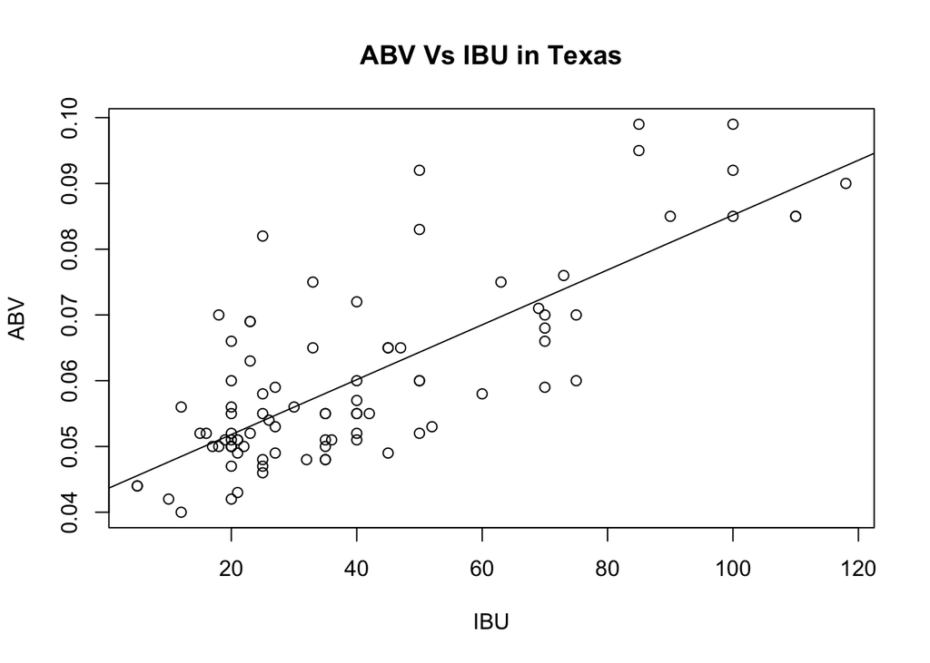

```r
abline(tx_lmt)
```

### We plot the relationship between ABV and IBU for the state of Colorado

```r
na.omit(combined) %>% filter(State=="CO") ->beerCO
head(beerCO)
```

```
##   Brew_ID                 Brewery_Name    City State
## 1       7 Great Divide Brewing Company  Denver    CO
## 2      38        Avery Brewing Company Boulder    CO
## 3      38        Avery Brewing Company Boulder    CO
## 4      38        Avery Brewing Company Boulder    CO
## 5      38        Avery Brewing Company Boulder    CO
## 6      52      Upslope Brewing Company Boulder    CO
##                              Beer_Name Beer_ID   ABV IBU
## 1                 Yeti  Imperial Stout    2644 0.095  75
## 2                 Avery India Pale Ale     107 0.063  69
## 3                    Ellie’s Brown Ale     106 0.055  17
## 4                         White Rascal     108 0.056  10
## 5 Avery Joe’s Premium American Pilsner     146 0.047  42
## 6                  Upslope Craft Lager     444 0.048  22
##                    Style Ounces
## 1 Russian Imperial Stout     12
## 2           American IPA     12
## 3     American Brown Ale     12
## 4                Witbier     12
## 5        German Pilsener     12
## 6           Vienna Lager     12
```

```r
plot(beerCO$ABV ~ beerCO$IBU, main= "ABV Vs IBU in Colorado", xlab = "IBU", ylab = "ABV")
co_lmc <- lm(beerCO$ABV ~ beerCO$IBU)
summary(co_lmc)
```

```
##
## Call:
## lm(formula = beerCO$ABV ~ beerCO$IBU)
##
## Residuals:
##       Min        1Q    Median        3Q       Max
## -0.018158 -0.007266 -0.003293  0.006453  0.032853
##
## Coefficients:
##              Estimate Std. Error t value Pr(>|t|)
## (Intercept) 4.740e-02  1.856e-03   25.54   <2e-16 ***
## beerCO$IBU  3.676e-04  3.432e-05   10.71   <2e-16 ***
## ---
## Signif. codes:  0 '***' 0.001 '**' 0.01 '*' 0.05 '.' 0.1 ' ' 1
##
## Residual standard error: 0.01077 on 144 degrees of freedom
## Multiple R-squared:  0.4433, Adjusted R-squared:  0.4395
## F-statistic: 114.7 on 1 and 144 DF,  p-value: < 2.2e-16
```

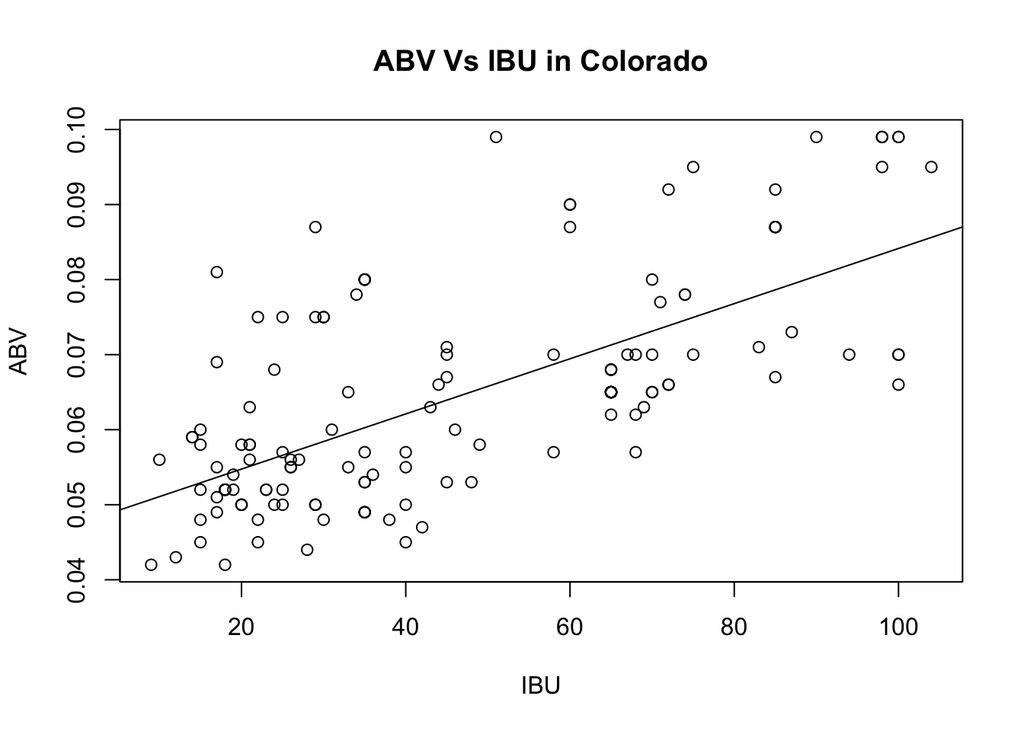

```r
abline(co_lmc)
```

### Addressing the assumption for Texas

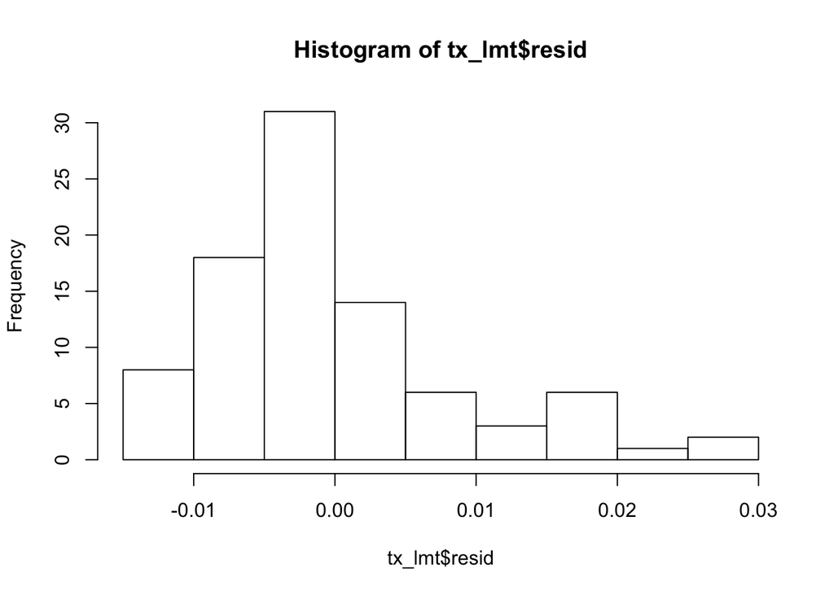

```r
hist(tx_lmt$resid)
```

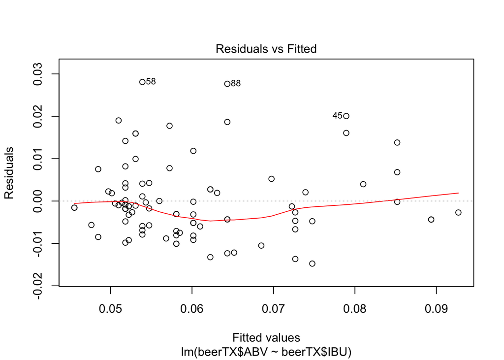

```r
plot(tx_lmt, which=1)
```

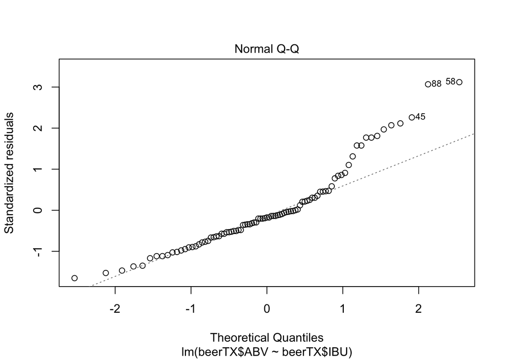

```r
plot(tx_lmt, which=2)
```

- 1-Subpopulation of ABV for a fixed IBU are not normally distributed for the state of Texas. Could be corrected with the removal of outlier in the higher end though, please refer to the histogram. The variation in the distribution of ABV is not the same, please refer to Residual Vs Fitted, different variation of the ABV across the plot.
- 2-The means of the distributions of ABV are linearly related to IBU.P value = <2e-16.
- 3-We can not assume that the mean and variation of the mean from the ABV are normaly distributed. Please refer to Residual Vs Fitted.
- 4-ABV and IBU are independent from one another.(No multicollinearity). Observations are independent of one another. Assuming in base of the knowledge in the colection of the data.

### Addressing the assumption for Colorado

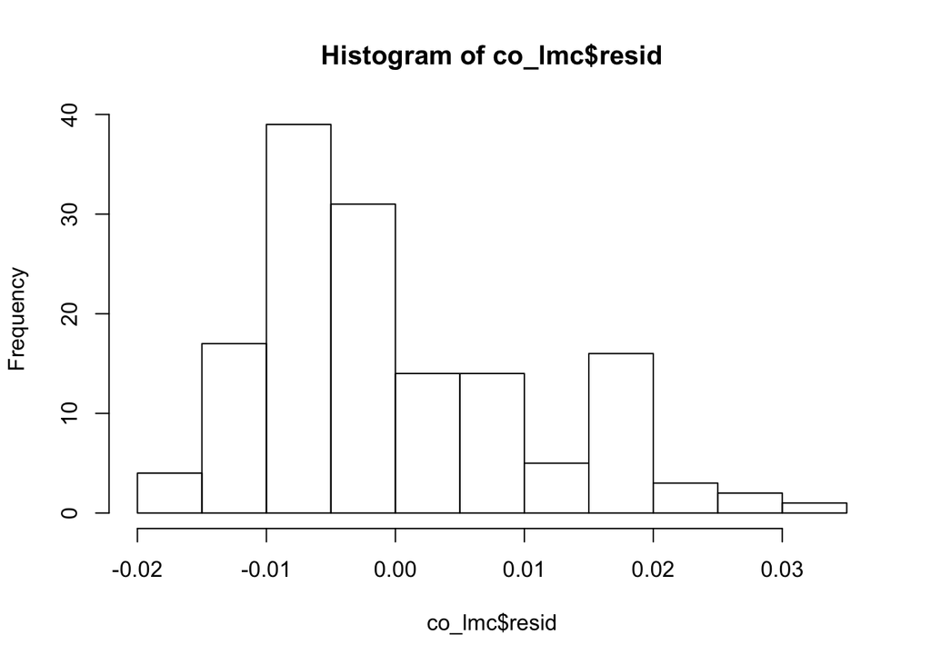

```r
hist(co_lmc$resid)
```

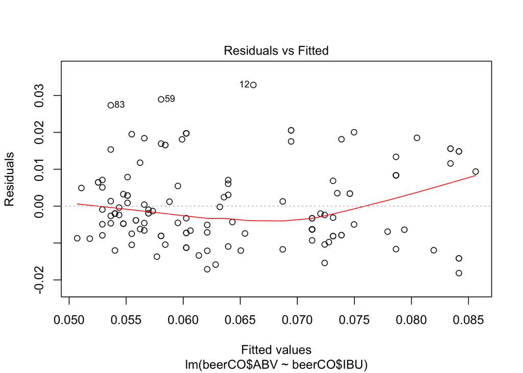

```r
plot(co_lmc, which=1)
```

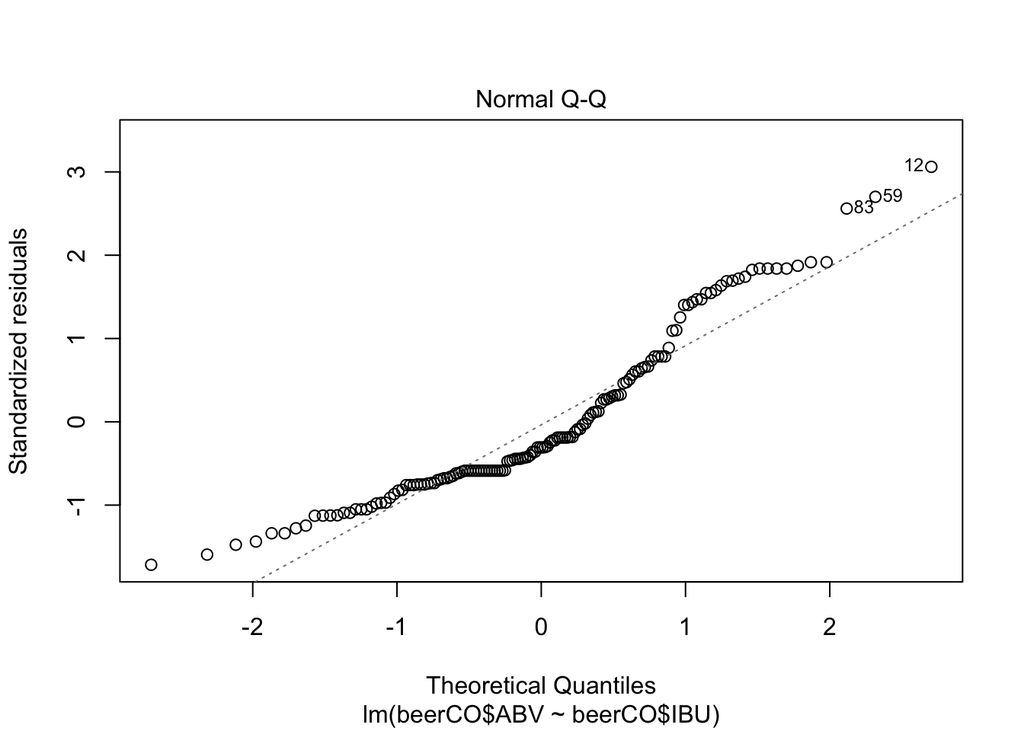

```r
plot(co_lmc, which=2)
```

- 1-Subpopulation of ABV for a fixed IBU are not normally distributed in the state of Colorado. Plese see histogram. Also the data is concentrated in the lower part of the plot Residual VS Fitted. The variation in the distribution of ABV is not the same, please refer to Residual Vs Fitted, different variation of the ABV across the plot.
- 2-The means of the distributions of ABV are linearly related to IBU.P value = <2e-16.
- 3-We can not assume that the mean and variation of the mean from the ABV are normaly distributed.Please refer to Residual Vs Fitted.
- 4-ABV and IBU are independent from one another.(No multicollinearity). Observations are independent of one another. Assuming in base of the knowledge in the colection of the data

# Questio D1

### Interpretation of the Slope for Texas

```r
summary(tx_lmt)
```

```
##
## Call:
## lm(formula = beerTX$ABV ~ beerTX$IBU)
##
## Residuals:
##       Min        1Q    Median        3Q       Max
## -0.014764 -0.005738 -0.001560  0.003182  0.028096
##
## Coefficients:
##              Estimate Std. Error t value Pr(>|t|)
## (Intercept) 4.347e-02  1.772e-03   24.54   <2e-16 ***
## beerTX$IBU  4.172e-04  3.683e-05   11.33   <2e-16 ***
## ---
## Signif. codes:  0 '***' 0.001 '**' 0.01 '*' 0.05 '.' 0.1 ' ' 1
##
## Residual standard error: 0.009078 on 87 degrees of freedom
## Multiple R-squared:  0.596,  Adjusted R-squared:  0.5914
## F-statistic: 128.3 on 1 and 87 DF,  p-value: < 2.2e-16
```

- Interpretation of the slope = For IBU in the state of Texas, for every increment in IBU, there is increasement in ABV by 4.172e-04*IBU.
- Interpretation of the intercept = When IBU is 0 in the state of Texas the ABV is 4.3473e-02

### Interpretation of the Slope for Colorado

```r
summary(co_lmc)
```

```
##
## Call:
## lm(formula = beerCO$ABV ~ beerCO$IBU)
##
## Residuals:
##       Min        1Q    Median        3Q       Max
## -0.018158 -0.007266 -0.003293  0.006453  0.032853
##
## Coefficients:
##              Estimate Std. Error t value Pr(>|t|)
## (Intercept) 4.740e-02  1.856e-03   25.54   <2e-16 ***
## beerCO$IBU  3.676e-04  3.432e-05   10.71   <2e-16 ***
## ---
## Signif. codes:  0 '***' 0.001 '**' 0.01 '*' 0.05 '.' 0.1 ' ' 1
##
## Residual standard error: 0.01077 on 144 degrees of freedom
## Multiple R-squared:  0.4433, Adjusted R-squared:  0.4395
## F-statistic: 114.7 on 1 and 144 DF,  p-value: < 2.2e-16
```

### Interpretation of the confident interval

```r
confint(tx_lmt)
```

```
##                   2.5 %       97.5 %
## (Intercept) 0.039952379 0.0469949413
## beerTX$IBU  0.000344007 0.0004903987
```

- For IBU in the state of Texas, for every increment in IBU, we will see increasement in the ABV by 4.172e-04xIBU. We are 95% confident that this increment in ABV will be between (0.000344007 - 0.0004903987)xUBU

```r
confint(co_lmc)
```

```
##                   2.5 %       97.5 %
## (Intercept) 0.043732505 0.0510700022
## beerCO$IBU  0.000299726 0.0004354124
```

- For IBU in the state of Colorado, for every increment in IBU, we will see increasement in the ABV by 3.676e-04xUBU We are 95% confident that this increment in ABV will be between (0.000299726 - 0.0004354124)xUBU
- In base of the plausible values of the intercept and the slope from Colorado and Texas,given by the confident interval, we dont have enough evidence that Texas and colorado have a different relationship.

# Question E

### Set the train and the test data from the Colorado and Texas dataframe

```r
df1<- mutate(beerCOTX, IBU2= IBU^2)
head(df1)
```

```
##   Brew_ID               Brewery_Name           City State
## 1      67   Freetail Brewing Company    San Antonio    TX
## 2     129   Real Ale Brewing Company         Blanco    TX
## 3     392       Breckenridge Brewery         Denver    CO
## 4      38      Avery Brewing Company        Boulder    CO
## 5      67   Freetail Brewing Company    San Antonio    TX
## 6     188 Pedernales Brewing Company Fredericksburg    TX
##               Beer_Name Beer_ID   ABV IBU                   Style Ounces
## 1    Yo Soy Un Berliner    2520 0.044   5      Berliner Weissbier     12
## 2 18th Anniversary Gose    2370 0.044   5                    Gose     12
## 3           Agave Wheat    1522 0.042   9 American Pale Wheat Ale     12
## 4          White Rascal     108 0.056  10                 Witbier     12
## 5               Rye Wit    2522 0.042  10                 Witbier     12
## 6             Lobo Lito    2238 0.040  12             Light Lager     12
##   IBU2
## 1   25
## 2   25
## 3   81
## 4  100
## 5  100
## 6  144
```

```r
## 60% and 40% of the sample size
smp_size <- floor(0.60 * nrow(df1))
## set the seed to make your partition reproducible
set.seed(123)
train_ind <- sample(seq_len(nrow(df1)), size = smp_size)
train <- df1[train_ind, ]
head(train)
```

```
##     Brew_ID                        Brewery_Name            City State
## 68      442       Pateros Creek Brewing Company    Fort Collins    CO
## 185     392                Breckenridge Brewery          Denver    CO
## 96      242        New Republic Brewing Company College Station    TX
## 205     127 Uncle Billy's Brewery and Smokeh...          Austin    TX
## 218      30                 Cedar Creek Brewery    Seven Points    TX
## 11       52             Upslope Brewing Company         Boulder    CO
##                              Beer_Name Beer_ID   ABV IBU
## 68                     Cache La Porter     694 0.050  24
## 185                        Lucky U IPA     193 0.062  68
## 96                             Kadigan    2042 0.056  30
## 205                     The Green Room    2372 0.060  75
## 218                         Gone A-Rye    2600 0.085  90
## 11  Top Rope Mexican-style Craft Lager     466 0.048  15
##                              Style Ounces IBU2
## 68                 American Porter     16  576
## 185                   American IPA     12 4624
## 96             American Blonde Ale     12  900
## 205                   American IPA     16 5625
## 218 American Double / Imperial IPA     16 8100
## 11                    Vienna Lager     12  225
```

```r
test <- df1[-train_ind, ]
head(test)
```

```
##    Brew_ID                   Brewery_Name           City State
## 2      129       Real Ale Brewing Company         Blanco    TX
## 3      392           Breckenridge Brewery         Denver    CO
## 4       38          Avery Brewing Company        Boulder    CO
## 6      188     Pedernales Brewing Company Fredericksburg    TX
## 7      216             Texian Brewing Co.       Richmond    TX
## 12      64 Crazy Mountain Brewing Company        Edwards    CO
##                Beer_Name Beer_ID   ABV IBU                   Style Ounces
## 2  18th Anniversary Gose    2370 0.044   5                    Gose     12
## 3            Agave Wheat    1522 0.042   9 American Pale Wheat Ale     12
## 4           White Rascal     108 0.056  10                 Witbier     12
## 6              Lobo Lito    2238 0.040  12             Light Lager     12
## 7          Broken Bridge    2117 0.056  12            Dunkelweizen     12
## 12         Lava Lake Wit     685 0.052  15                 Witbier     12
##    IBU2
## 2    25
## 3    81
## 4   100
## 6   144
## 7   144
## 12  225
```

### Training data

```r
na.omit(train) %>% filter(State=="TX") -> dftt
head(dftt)
```

```
##   Brew_ID                        Brewery_Name            City State
## 1     242        New Republic Brewing Company College Station    TX
## 2     127 Uncle Billy's Brewery and Smokeh...          Austin    TX
## 3      30                 Cedar Creek Brewery    Seven Points    TX
## 4     119       Southern Star Brewing Company          Conroe    TX
## 5      30                 Cedar Creek Brewery    Seven Points    TX
## 6     396                Hops & Grain Brewery          Austin    TX
##              Beer_Name Beer_ID   ABV IBU                          Style
## 1              Kadigan    2042 0.056  30            American Blonde Ale
## 2       The Green Room    2372 0.060  75                   American IPA
## 3           Gone A-Rye    2600 0.085  90 American Double / Imperial IPA
## 4        Old Potentate    1010 0.072  40                        Old Ale
## 5 Scruffy's Smoked Alt    1584 0.051  35                    Smoked Beer
## 6             Pale Dog     501 0.060  50        American Pale Ale (APA)
##   Ounces IBU2
## 1     12  900
## 2     16 5625
## 3     16 8100
## 4     12 1600
## 5     16 1225
## 6     12 2500
```

```r
na.omit(train) %>% filter(State=="CO") -> dftc
```

### Test data

```r
na.omit(test) %>% filter(State=="TX") -> dftet
head(dftet)
```

```
##   Brew_ID               Brewery_Name           City State
## 1     129   Real Ale Brewing Company         Blanco    TX
## 2     188 Pedernales Brewing Company Fredericksburg    TX
## 3     216         Texian Brewing Co.       Richmond    TX
## 4     188 Pedernales Brewing Company Fredericksburg    TX
## 5      30        Cedar Creek Brewery   Seven Points    TX
## 6     258       South Austin Brewery   South Austin    TX
##                     Beer_Name Beer_ID   ABV IBU            Style Ounces
## 1       18th Anniversary Gose    2370 0.044   5             Gose     12
## 2                   Lobo Lito    2238 0.040  12      Light Lager     12
## 3               Broken Bridge    2117 0.056  12     Dunkelweizen     12
## 4 Robert Earl Keen Honey Pils    2144 0.050  17 American Pilsner     12
## 5             The Lawn Ranger    1050 0.050  18        Cream Ale     16
## 6                  LuckenBock    1972 0.070  18             Bock     16
##   IBU2
## 1   25
## 2  144
## 3  144
## 4  289
## 5  324
## 6  324
```

```r
na.omit(test) %>% filter(State=="CO") -> dftec
head(dftec)
```

```
##   Brew_ID                   Brewery_Name    City State           Beer_Name
## 1     392           Breckenridge Brewery  Denver    CO         Agave Wheat
## 2      38          Avery Brewing Company Boulder    CO        White Rascal
## 3      64 Crazy Mountain Brewing Company Edwards    CO       Lava Lake Wit
## 4     136             Pug Ryan's Brewery  Dillon    CO     Dead Eye Dunkel
## 5     265            Ska Brewing Company Durango    CO Estival Cream Stout
## 6     136             Pug Ryan's Brewery  Dillon    CO      Hideout Helles
##   Beer_ID   ABV IBU                   Style Ounces IBU2
## 1    1522 0.042   9 American Pale Wheat Ale     12   81
## 2     108 0.056  10                 Witbier     12  100
## 3     685 0.052  15                 Witbier     12  225
## 4    1462 0.060  15     Munich Dunkel Lager     12  225
## 5    1297 0.058  15          American Stout     12  225
## 6    1463 0.069  17     Munich Helles Lager     12  289
```

### Model 1 Texas

```r
texas <- lm(dftt$ABV ~dftt$IBU) # We predict ABV in base of number given by IBU
summary(texas)
```

```
##
## Call:
## lm(formula = dftt$ABV ~ dftt$IBU)
##
## Residuals:
##       Min        1Q    Median        3Q       Max
## -0.012599 -0.006095 -0.001766  0.002405  0.028871
##
## Coefficients:
##              Estimate Std. Error t value Pr(>|t|)
## (Intercept) 4.419e-02  2.553e-03  17.312  < 2e-16 ***
## dftt$IBU    3.788e-04  5.375e-05   7.047 5.07e-09 ***
## ---
## Signif. codes:  0 '***' 0.001 '**' 0.01 '*' 0.05 '.' 0.1 ' ' 1
##
## Residual standard error: 0.0095 on 50 degrees of freedom
## Multiple R-squared:  0.4983, Adjusted R-squared:  0.4882
## F-statistic: 49.66 on 1 and 50 DF,  p-value: 5.07e-09
```

```r
# prediction 1
predict1 <- predict.lm(texas, dftet)
head(predict1)
```

```
##          1          2          3          4          5          6
## 0.05555340 0.07259852 0.07828023 0.05934121 0.05744730 0.06312901
```

### Calculate ASE of model 1 Texas

```r
ASA1 <- mean((predict1-dftet$ABV)^2)
ASA1
```

```
## [1] 0.000290054
```

### Model 2 Texas

```r
texas2 <- lm( dftt$ABV ~ dftt$IBU + dftt$IBU2 , data  = dftt)
summary(texas2)
```

```
##
## Call:
## lm(formula = dftt$ABV ~ dftt$IBU + dftt$IBU2, data = dftt)
##
## Residuals:
##       Min        1Q    Median        3Q       Max
## -0.011972 -0.005940 -0.001919  0.001845  0.030021
##
## Coefficients:
##              Estimate Std. Error t value Pr(>|t|)
## (Intercept) 4.747e-02  4.726e-03  10.045 1.73e-13 ***
## dftt$IBU    2.171e-04  2.030e-04   1.070    0.290
## dftt$IBU2   1.461e-06  1.768e-06   0.826    0.413
## ---
## Signif. codes:  0 '***' 0.001 '**' 0.01 '*' 0.05 '.' 0.1 ' ' 1
##
## Residual standard error: 0.009531 on 49 degrees of freedom
## Multiple R-squared:  0.5052, Adjusted R-squared:  0.485
## F-statistic: 25.01 on 2 and 49 DF,  p-value: 3.267e-08
```

```r
predict2 <- predict.lm(texas2, dftet)
head(predict2)
```

```
##          1          2          3          4          5          6
## 0.05529947 0.07197208 0.07884414 0.05849329 0.05685987 0.06197923
```

### Calculate ASE of model 2 Texas

```r
ASA2 <-mean((predict2-dftet$ABV)^2)
ASA2
```

```
## [1] 0.0002929901
```

### Model 1 Colorado

```r
colorado <- lm(dftc$ABV ~dftc$IBU) # We predict ABV in base of number given by IBU
summary(colorado)
```

```
##
## Call:
## lm(formula = dftc$ABV ~ dftc$IBU)
##
## Residuals:
##       Min        1Q    Median        3Q       Max
## -0.018900 -0.006477 -0.003369  0.007853  0.020441
##
## Coefficients:
##              Estimate Std. Error t value Pr(>|t|)
## (Intercept) 4.655e-02  2.213e-03  21.035  < 2e-16 ***
## dftc$IBU    3.835e-04  4.065e-05   9.434 5.79e-15 ***
## ---
## Signif. codes:  0 '***' 0.001 '**' 0.01 '*' 0.05 '.' 0.1 ' ' 1
##
## Residual standard error: 0.01014 on 87 degrees of freedom
## Multiple R-squared:  0.5057, Adjusted R-squared:    0.5
## F-statistic: 89.01 on 1 and 87 DF,  p-value: 5.794e-15
```

```r
# prediction 1
predict3 <- predict.lm(colorado, dftec)
head(predict3)
```

```
##          1          2          3          4          5          6
## 0.05575278 0.07262753 0.05230113 0.06035499 0.07531215 0.07914732
```

### Calculate ASE of model 1 Colorado

```r
ASA3<- mean((predict3-dftec$ABV)^2)
ASA3
```

```
## [1] 0.0002727333
```

### Model 2 Colorado

```r
colorado2 <- lm( dftc$ABV ~ dftc$IBU + dftc$IBU2 , data  = dftc)
summary(colorado2)
```

```
##
## Call:
## lm(formula = dftc$ABV ~ dftc$IBU + dftc$IBU2, data = dftc)
##
## Residuals:
##       Min        1Q    Median        3Q       Max
## -0.020470 -0.005908 -0.002807  0.006567  0.021209
##
## Coefficients:
##              Estimate Std. Error t value Pr(>|t|)
## (Intercept) 4.891e-02  4.424e-03  11.057   <2e-16 ***
## dftc$IBU    2.648e-04  1.962e-04   1.350    0.181
## dftc$IBU2   1.107e-06  1.790e-06   0.618    0.538
## ---
## Signif. codes:  0 '***' 0.001 '**' 0.01 '*' 0.05 '.' 0.1 ' ' 1
##
## Residual standard error: 0.01018 on 86 degrees of freedom
## Multiple R-squared:  0.5079, Adjusted R-squared:  0.4964
## F-statistic: 44.38 on 2 and 86 DF,  p-value: 5.739e-14
```

```r
predict4 <- predict.lm(colorado2, dftec)
head(predict4)
```

```
##          1          2          3          4          5          6
## 0.05590840 0.07204340 0.05313616 0.05988371 0.07500558 0.07942548
```

### Calculate ASE for model 2 Colorado

```r
ASA4<- mean((predict4-dftec$ABV)^2)
ASA4
```

```
## [1] 0.0002736109
```

### Given all the values of ASE, I conclude that none of the models are much better than each other. The model 1 for colorado seen to be the best by 0.00000088.